# catalonia

*April 24th, 2023*

*Group 15*

*Milestone 4*

Jongkyung Kim  
ckim4@g.harvard.edu

James Liounis

jamesliounis@g.harvard.edu

Tadhg Looram

tadhglooram@g.harvard.edu

Elaine Swanson

cswanson@g.harvard.edu

Yanis Vandecasteele

yanis_vandecasteele@g.harvard.edu

# Problem Statement

The motivation of this project is to address the need for accurate and timely information about the Earth's surface and understanding flux in the environment's soil moisture during the climate change era. This information is crucial for several reasons:

1. Plant growth and health: Plants need water to survive, and the amount of moisture in the soil directly affects their ability to take up water and nutrients from the soil. If soil moisture is too low, plants may wilt and die, and if it's too high, plants may suffer from root rot.
2. Agriculture: Farmers need to know how much moisture is in the soil to determine when to irrigate their crops. Over-irrigation can lead to water waste and leaching of nutrients, while under-irrigation can result in crop failure.
3. Water management: It affects the amount of water that can be stored in the soil and the rate at which water moves through the soil. Understanding soil moisture can help manage water resources, such as groundwater recharge, reservoir storage, and flood control.
4. Climate modeling: It affects the exchange of water and energy between the land surface and the atmosphere, which influences weather patterns and climate variability.

# Imports and authentication

```python
# Run these and then comment out after running. Do not modify!!
# !pip install rasterio
# !pip install gcsfs
# !pip install hvplot
# !pip install earthengine-api
# !pip install tensorflow
# !pip install geopandas
# !pip install statsmodels
# !pip install folium
# !pip install xarray
```

```python
from google.cloud import storage
from google.oauth2 import service_account
```

```python
import matplotlib.pyplot as plt
import folium
import os

import requests
from datetime import datetime, timedelta

from PIL import Image
from io import BytesIO
import re

import colorcet as cc
import numpy as np

import time
from tqdm import tqdm

import pandas as pd
import random

import pickle
import rasterio
import gcsfs
import shutil
from scipy import stats

import xarray as xr
import hvplot.xarray

from IPython.display import display

from rasterio.io import MemoryFile

import ee
import folium
import xarray as xr
import tensorflow as tf
from tensorflow import keras
import geopandas as gpd

import statsmodels.api as sm
from pylab import rcParams
```

# Downloading images from Google Cloud Platform Bucket onto local machine

```python
# Path to your JSON key file in Google Drive
key_file_path = 'key-file.json'
# Create Google Cloud Storage API credentials
credentials = service_account.Credentials.from_service_account_file(key_file_path)

# Initialize the Google Cloud Storage client with the custom credentials
client = storage.Client(credentials=credentials)
```

```python
# Reduced Bucket
# Set up the GCS client for grabbing data for analysis
os.environ["GOOGLE_APPLICATION_CREDENTIALS"] = key_file_path
client = storage.Client()
bucket_name = "smap-satellite-images-reduced"
bucket = client.get_bucket(bucket_name)
```

```python
# Non-reduced Bucket
# Set up the GCS client for grabbing data for map visualization
bucket_name_for_maps = "smap-satellite-images"
bucket_for_maps = client.get_bucket(bucket_name_for_maps)
```

# Downloading one day snap shots of the Spain/Portugal region for visualization

```python
# List the files in the GCP bucket
blobs_for_maps = list(bucket_for_maps.list_blobs())

# Download the GeoTIFF files and store them in the dictionary
file_patterns = {
    'sm': re.compile(r'^smSurface_\d{4}-\d{2}-\d{2}\.tif$'),
    'temp': re.compile(r'^surface_temp_\d{4}-\d{2}-\d{2}\.tif$'),
    'evap': re.compile(r'^evapotranspiration_\d{4}-\d{2}-\d{2}\.tif$'),
    'precip': re.compile(r'^precipitation_\d{4}-\d{2}-\d{2}\.tif$'),
}
geo_files_for_maps = {key: [] for key in file_patterns}

# Group blobs by file type
blobs_by_type_for_maps = {key: [] for key in file_patterns}
for blob2 in blobs_for_maps:
    file_name = blob2.name
    for key, pattern in file_patterns.items():
        if pattern.match(file_name):
            blobs_by_type_for_maps[key].append(blob2)

# Download files with progress bars
for key, blob_list in blobs_by_type_for_maps.items():
    print(f'Downloading {key} files:')
    # pull the most k many recent days of images
    for blob in tqdm(blob_list[-1:]):
        # Read the GeoTIFF file into memory and open it using rasterio
        with MemoryFile(blob.download_as_bytes()) as memfile:
            with memfile.open() as dataset:
                # Read the pixel values for the first band as a NumPy array
                data = dataset.read(1)
                # Replace NoData values with NaN
                data[np.isinf(data)] = np.nan
                geo_files_for_maps[key].append((data, blob.name))
```

```
Downloading sm files:
```

```
Downloading temp files:
```

```
Downloading evap files:
```

```
Downloading precip files:
```

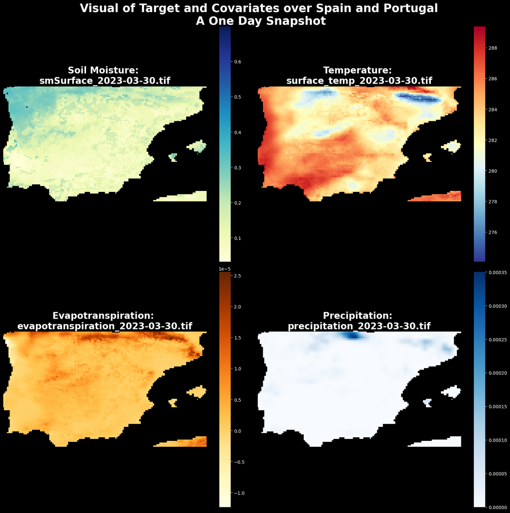

```python
# Define the data and colormap for each subplot
data_list = [geo_files_for_maps['sm'][0][0], geo_files_for_maps['temp'][0][0], geo_files_for_maps['evap'][0][0], geo_files_for_maps['precip'][0][0]]
cmap_list = [plt.cm.YlGnBu, plt.cm.RdYlBu_r, plt.cm.YlOrBr, plt.cm.Blues]

# Define the extent of the region
xmin, ymin, xmax, ymax = [-9.296875, 36.137874, 3.515625, 43.389081]
title_list = [f"Soil Moisture: \n{geo_files_for_maps['sm'][0][1]}", f"Temperature: \n{geo_files_for_maps['temp'][0][1]}", f"Evapotranspiration: \n{geo_files_for_maps['evap'][0][1]}", f"Precipitation: \n{geo_files_for_maps['precip'][0][1]}"]

colorbar_list = []
fig, axs = plt.subplots(nrows=2, ncols=2, figsize=(16, 16), facecolor='k')
# Loop through the subplots
for i, ax in enumerate(axs.flat):
    extent = [xmin, xmax, ymin, ymax]
    cmap = cmap_list[i]
    cmap.set_bad(color='black')
    im = ax.imshow(data_list[i], extent=extent, cmap=cmap)
    ax.set_title(title_list[i], color='white', fontsize=20, fontweight='bold')
    colorbar = fig.colorbar(im, ax=ax)
    colorbar.ax.tick_params(colors='white')
    colorbar_list.append(colorbar)

# Turn off the axis for all subplots
for ax in axs.flat:
    ax.set_axis_off()

fig.suptitle('Visual of Target and Covariates over Spain and Portugal\n A One Day Snapshot', fontsize=25, fontweight='bold', color='white')
plt.tight_layout()
plt.show()
```

# Downloading 8 years of the reduced (Catalonia) data from the GCP for analysis

```python
# Download files with progress bars
# List the files in the GCP bucket
blobs = list(bucket.list_blobs())
# Download the GeoTIFF files and store them in the dictionary
file_patterns = {
    'sm': re.compile(r'^smSurface_\d{4}-\d{2}-\d{2}\.tif$'),
    'temp': re.compile(r'^surface_temp_\d{4}-\d{2}-\d{2}\.tif$'),
    'evap': re.compile(r'^evapotranspiration_\d{4}-\d{2}-\d{2}\.tif$'),
    'precip': re.compile(r'^precipitation_\d{4}-\d{2}-\d{2}\.tif$'),
}

geo_files = {key: [] for key in file_patterns}
# Group blobs by file type
blobs_by_type = {key: [] for key in file_patterns}
for blob in blobs:
    file_name = blob.name
    for key, pattern in file_patterns.items():
        if pattern.match(file_name):
            blobs_by_type[key].append(blob)

# Set k value, number of images you want to pull
# k = 365

# Download files with progress bars
for key, blob_list in blobs_by_type.items():
    print(f'Downloading {key} files:')
    # pull the most k many recent days of images
    for blob in tqdm(blob_list):
        # Read the GeoTIFF file into memory and open it using rasterio
        with MemoryFile(blob.download_as_bytes()) as memfile:
            with memfile.open() as dataset:
                # Read the pixel values for the first band as a NumPy array
                data = dataset.read(1)
                # Replace NoData values with NaN
                data[np.isinf(data)] = np.nan
                geo_files[key].append((data, blob.name)) # Append tuple containing data and file name
```

```
Downloading sm files:
```

```
Downloading temp files:
```

```
Downloading evap files:
```

```
Downloading precip files:
```

```python
## Select three random elements from image_tuple to visualize
random_file_names = []
random_file_data = []

for category, image_tuple in geo_files.items():
    random_samples = random.sample(image_tuple, 3)

    for data, name in random_samples:
        random_file_data.append(data)
        random_file_names.append(name[:-4])
random_file_data = np.array(random_file_data)
random_file_name = np.array(random_file_names)
```

```python
## Modify plot function to output an entire subplot with labels in title
def plot_images(file_data, file_names):
    fig, axes = plt.subplots(4, 3, figsize=(15, 15))
    fig.subplots_adjust(hspace=0.4)
    fig.suptitle("Three Random Images per Variable", fontsize=20, y=0.95)
    categories = list(geo_files.keys())
    for i in range(len(categories)):
        for j in range(3):
            img_data = file_data[i*3+j]
            img_name = file_names[i*3+j]
            ax = axes[i, j]
            im = ax.imshow(img_data, cmap='viridis')
            ax.set_title(f'Image {j + 1}: {img_name}')
            ax.axis('off')
            # Add a colorbar
            fig.colorbar(im, ax=ax, orientation='vertical', fraction=0.046, pad=0.04)

    plt.show()
```

## Visualizing 3 random images from the reduced data set: Catalonia/Barcelona region.

```python
plot_images(random_file_data, random_file_names)
```

[output not shown]

# Beginning of EDA

### Data Summary

```python
# geo_files is a dictionnary
type(geo_files)
```

```python
# keys: sm for Soil Moisture / surface_temp for Surface Temperature / evapotranspiration / precipitation
geo_files.keys()
```

```python
# values: list of tuples:
# tuple[0]: numpy arrays containing the values for each feature
# tuple[1]: name of the numpy array

print(f"Time period: {len(geo_files['sm'])} days\n")

print(f"Example first day: values of Soil Moisture as type {type(geo_files['sm'][0][0])}:\n\n {geo_files['sm'][0][0]}\n\n")

print(f"Example first day: name of Soil Moisture as type {type(geo_files['sm'][0][1])}:\n {geo_files['sm'][0][1]}\n\n")

print(f"Example last day: values of Soil Moisture as type {type(geo_files['sm'][0][0])}:\n\n {geo_files['sm'][-1][0]}\n\n")

print(f"Example last day: name of Soil Moisture as type {type(geo_files['sm'][0][1])}:\n {geo_files['sm'][-1][1]}\n\n")

print(f"Shapes of arrays per category, corresponding to geographic region:\n\nSoil Moisture: {geo_files['sm'][1][0].shape}\nPrecipitation: {geo_files['precip'][1][0].shape} \nEvapotranspiration: {geo_files['evap'][1][0].shape} \nSurface Temperature: {geo_files['temp'][1][0].shape}\n\n")

#https://stackoverflow.com/questions/6736590/fast-check-for-nan-in-numpy
print(f"Check NaN in arrays per category. This represents water, not land:\n\nSoil Moisture: {np.isnan(np.sum(geo_files['sm'][1][0]))}\nPrecipitation: {np.isnan(np.sum(geo_files['precip'][1][0]))} \nEvapotranspiration: {np.isnan(np.sum(geo_files['evap'][1][0]))} \nSurface Temperature: {np.isnan(np.sum(geo_files['temp'][1][0]))}")
```

### Summary Statistics

```python
length = len(geo_files['sm'])
length
```

```python
# Trim off the extra two days in temperature
geo_files['temp'] = geo_files['temp'][:-2]
```

```python
# Creating averages, maxes, and mins into dictionaries
vars = ['sm','temp','evap','precip']
avgs = {var: [] for var in vars}
maxes = {var: [] for var in vars}
mins = {var: [] for var in vars}
```

```python
for var in vars:
    for i in range(length):
        avgs[var].append(np.nanmean(geo_files[var][i][0]))
        maxes[var].append(np.nanmax(geo_files[var][i][0]))
        mins[var].append(np.nanmin(geo_files[var][i][0]))
```

# Explore the spread, seasonality, trends, and other characteristics of our data

```python
# Ignoring xtick warnings
import warnings
warnings.filterwarnings("ignore")
```

```python
fig, axs = plt.subplots(2, 2, figsize=(15, 13))
axs = axs.flat

plt.suptitle('Histograms of Target and Predictor Variables\nPer day average for Catalonia region\n(2015 - 2023)\n', fontsize = '25')

for var, ax in zip(vars, axs):
    ax.set_facecolor('antiquewhite')
    ax.grid(color='darkslategrey', alpha=0.5, linestyle='dashed', linewidth=1)
    ax.hist(avgs[var], color='darkslategrey', bins = 25, edgecolor = 'white')
    ax.set_title(f'Average {var}', fontsize= '20')
    ax.set_xlabel(f'Average {var} Per Day')
    ax.set_ylabel('Count')

plt.tight_layout()
plt.show()
```

```python
x = np.arange('2015-03-31', '2023-04-26', dtype='datetime64[D]')


fig, axs = plt.subplots(2,2, figsize=(15,13))
plt.suptitle('Daily Average of Target and Predictor Variables\nPer day average for Catalonia region\n(2015 - 2023)\n', fontsize = '25')
axs = axs.flatten()

x_tickz = ['No Data', '2015', '2016', '2017', '2018', '2019', '2020', '2021', '2022', '2023']
for i, var in enumerate(vars):
    axs[i].plot(x, avgs[var], color='darkslategrey')
    axs[i].set_xlabel('Date')
    axs[i].set_ylabel(f'{var} data')
    axs[i].set_title(f'Daily Average "{var}"', fontsize= '20')
    axs[i].set_facecolor('antiquewhite')
    axs[i].grid(color='darkslategrey', alpha=0.5, linestyle='dashed', linewidth=1)
    axs[i].set_xticklabels(x_tickz, rotation=30)
plt.tight_layout()
plt.show()
```

[output not shown]

```python
fig, axs = plt.subplots(2,2, figsize=(17,15))
plt.suptitle('Daily Max and Min of Target and Predictor Variables\nPer day average for Catalonia region\n(2015 - 2023)\n', fontsize = '25')
axs = axs.flatten()

for i, var in enumerate(vars):
    axs[i].plot(x, maxes[var], label='Max', color='tomato')
    axs[i].plot(x, mins[var], label='Min', color='cadetblue')
    axs[i].set_xlabel('Date')
    axs[i].set_ylabel(f'{var} data')
    axs[i].set_title(f'Daily Min and Max "{var}"', fontsize = '20')
    axs[i].set_facecolor('antiquewhite')
    axs[i].grid(color='darkslategrey', alpha=0.5, linestyle='dashed', linewidth=1)
    axs[i].set_xticklabels(x_tickz, rotation=30)

legend = plt.legend(loc='upper center', bbox_to_anchor=(1.15, 0.3), shadow=True, labelcolor='w', fontsize='large')
legend.get_texts()[0].set_color("black")
legend.get_texts()[1].set_color("black")
legend.get_frame().set_facecolor('antiquewhite')
plt.tight_layout()
plt.show()
```

# Correlation plot

We inspect the correlation among our covariates.

```python
# Create a dataframe of daily averages
d = {"avg_"+name: avgs[name] for name in vars}
df = pd.DataFrame(d)
df_head = df.head(10)
styled_df = df_head.style\
                .set_properties(subset=df_head.columns[:4], **{'background-color': 'tomato'})\
                .set_table_styles([{'selector': 'th', 'props': [('border', '1px solid cadetblue')]}])
styled_df
```

```python
# https://stackoverflow.com/questions/29432629/plot-correlation-matrix-using-pandas

# Compute pairwise correlation among our variables
corr = df.corr()
corr.style.background_gradient(cmap='coolwarm')
# Fill diagonal and upper half with NaNs
mask = np.zeros_like(corr, dtype=bool)
mask[np.triu_indices_from(mask)] = True
corr[mask] = np.nan
(corr
 .style.set_caption("Correlation Matrix of the features' daily averages").set_table_styles([{
    'selector': 'caption',
    'props': [
        ('color', 'tomato'),
        ('font-size', '20px')
    ]
}])
 .background_gradient(cmap='coolwarm', axis=None, vmin=-1, vmax=1)
 .highlight_null(color='#f1f1f1')  # Color NaNs grey
 .format(precision=2))
```

# EDA: Seasonality

### In the following, we consider additive models since the seasonality magnitude seems to remain approximately constant over time in our time series.

```python
# https://stackoverflow.com/questions/45184055/how-to-plot-multiple-seasonal-decompose-plots-in-one-figure
# Defining the function we will use.

def plotseasonal(res, fig, axes, period, var):
    lines = [(res.observed, 'Observed'), (res.trend, 'Trend'), (res.seasonal, 'Seasonal')]
    x = np.arange(len(res.trend))
    axes[0].set_title(f'Daily Average "{var}" Data Decompostion \n Period: {period}', fontsize=13)
    for i in range(3):
      axes[i].plot(x, lines[i][0], color='darkslategrey', linewidth=0.9)
      axes[i].set_ylabel(lines[i][1])
      axes[i].set_facecolor('antiquewhite')
      axes[i].grid(color='darkslategrey', alpha=0.5, linestyle='dashed', linewidth=1)
    axes[3].scatter(x, res.resid, s=5, color='darkslategrey')
    axes[3].axhline(y=0, color='black', linestyle='-')
    axes[3].set_ylabel('Residual')
    axes[3].set_facecolor('antiquewhite')
    axes[3].grid(color='darkslategrey', alpha=0.5, linestyle='dashed', linewidth=1)
    axes[3].set_xlabel("Date (in days)")
    fig.suptitle(f"{period} Decomposition of daily averages time series", y=1.02, fontsize=22)

# Zoom in seasonality
def zoom_in_seasonality(res, fig, axes, period, var):
    x = np.arange(len(res.seasonal))
    axes.set_title(f'Daily Average "{var}" Data Decompostion \n Period: {period}', fontsize=13)
    axes.plot(x[-70:], res.seasonal[-70:], color='darkslategrey', linewidth=3)
    axes.set_xlabel('Date (in days)')
    axes.set_ylabel('Seasonal')
    axes.set_facecolor('antiquewhite')
    axes.grid(color='darkslategrey', alpha=0.5, linestyle='dashed', linewidth=1)
    fig.suptitle(f"Zoom in seasonality for {period} Decomposition of daily averages (last 70 days)", y=1.02, fontsize=22)
```

*The code below creates an empty dictionary quarter_seasonality. It then iterates over a list of variables vars and applies the statsmodels.tsa.seasonal.seasonal_decompose function, and we're specifically looking at 'observed', 'trend', 'seasonal', and 'residuals'.*

- *'Observed': observed values!*
- *'Trend': The trend component represents the long-term movement of a time series over time. It is often described as the underlying growth or decline of the time series, and it can be influenced by many factors such as economic conditions, demographic changes, and technological advances. The trend component is typically estimated using a smoothing technique such as a moving average or a regression model. In a decomposed time series, the trend component represents the estimated long-term pattern in the data, after removing the seasonal and residual components.*
- *'seasonal': The seasonal component represents the regular and repeating patterns in a time series that occur within a fixed time period. For example, daily temperature measurements may exhibit a seasonal pattern where temperatures are higher in the summer and lower in the winter. The seasonal component is typically estimated by averaging the values of the time series over each season and subtracting the average value from each individual observation. In a decomposed time series, the seasonal component represents the estimated pattern in the data that repeats on a fixed time scale (i.e., the estimated seasonal variation).*
- *'residuals': The estimated residual component of the time series (i.e., the part of the time series that cannot be explained by the trend or seasonal components).*

*We perform this analysis for Annual, Quarterly, Monthly, and Weekly bases.*

## Annually

```python
yearly_seasonality = {}
for var in vars:
  yearly_seasonality[var] = sm.tsa.seasonal_decompose(avgs[var], period=365)
```

```python
fig, axes = plt.subplots(ncols=len(yearly_seasonality), nrows=4, sharex=True, figsize=(20,15))

for i, var in enumerate(vars):
  plotseasonal(yearly_seasonality[var], fig, axes[:,i], 'Annually', var)

plt.tight_layout()
plt.show()
```

```python
fig, axes = plt.subplots(ncols=len(yearly_seasonality), nrows=1, sharex=True, figsize=(25,8))

for i, var in enumerate(vars):
  zoom_in_seasonality(yearly_seasonality[var], fig, axes[i], 'Annually', var)

plt.tight_layout()
plt.show()
```

## Quarterly

```python
quarter_seasonality = {}
for var in vars:
  quarter_seasonality[var] = sm.tsa.seasonal_decompose(avgs[var], period=90)
```

```python
fig, axes = plt.subplots(ncols=len(quarter_seasonality), nrows=4, sharex=True, figsize=(20,15))

for i, var in enumerate(vars):
  plotseasonal(quarter_seasonality[var], fig, axes[:,i], 'Quarterly', var)

plt.tight_layout()
plt.show()
```

```python
fig, axes = plt.subplots(ncols=len(quarter_seasonality), nrows=1, sharex=True, figsize=(25,8))

for i, var in enumerate(vars):
  zoom_in_seasonality(quarter_seasonality[var], fig, axes[i], 'Quarterly', var)

plt.tight_layout()
plt.show()
```

## Monthly

```python
month_seasonality = {}
for var in vars:
  month_seasonality[var] = sm.tsa.seasonal_decompose(avgs[var], period=30)
```

```python
fig, axes = plt.subplots(ncols=len(month_seasonality), nrows=4, sharex=True, figsize=(20,15))

for i, var in enumerate(vars):
  plotseasonal(month_seasonality[var], fig, axes[:,i], 'Monthly', var)

plt.tight_layout()
plt.show()
```

```python
fig, axes = plt.subplots(ncols=len(month_seasonality), nrows=1, sharex=True, figsize=(25,8))

for i, var in enumerate(vars):
  zoom_in_seasonality(month_seasonality[var], fig, axes[i], 'Monthly', var)

plt.tight_layout()
plt.show()
```

## Weekly

```python
week_seasonality = {}
for var in vars:
  week_seasonality[var] = sm.tsa.seasonal_decompose(avgs[var], period=7)
```

```python
fig, axes = plt.subplots(ncols=len(week_seasonality), nrows=4, sharex=True, figsize=(25,15))

for i, var in enumerate(vars):
  plotseasonal(week_seasonality[var], fig, axes[:,i], 'Weekly', var)

plt.tight_layout()
plt.show()
```

```python
fig, axes = plt.subplots(ncols=len(week_seasonality), nrows=1, sharex=True, figsize=(25,8))

for i, var in enumerate(vars):
  zoom_in_seasonality(week_seasonality[var], fig, axes[i], 'Weekly', var)

plt.tight_layout()
plt.show()
```

# Seasonality: autocorrelations

```python
from statsmodels.tsa.stattools import pacf
from statsmodels.graphics.tsaplots import plot_pacf
from matplotlib.collections import PolyCollection, LineCollection
```

```python
# https://stackoverflow.com/questions/65870368/how-to-change-color-in-statsmodels-plot-acf-function
# https://stats.stackexchange.com/questions/305686/what-does-it-mean-if-the-partial-auto-correlation-function-of-a-time-series-have

lags = 181 #number of days to observe
curr_fig, axs = plt.subplots(2,2,figsize=(15, 12))
axs = axs.flat

plt.suptitle('Partial Autocorrelations of Daily Average of \n Target and Predictor Variables for 181 days', fontsize = 22)

for var,ax in zip(vars, axs):

    plot_pacf(avgs[var], lags=lags, title= f"Partial Autocorrelations of {var} Daily averages", auto_ylims=True, ax=ax)

    my_color="darkslategrey"

    for item in ax.collections:
      #change the color of the CI
      if type(item)==PolyCollection:
          item.set_facecolor(my_color)
      #change the color of the vertical lines
      if type(item)==LineCollection:
          item.set_color(my_color)

    #change the color of the markers/horizontal line
    for item in ax.lines:
        item.set_color(my_color)

    ax.set_facecolor('antiquewhite')
    #curr_ax.grid(color='darkslategrey', alpha=0.5, linestyle='dashed', linewidth=1)
    ax.grid()
    ax.set_ylim(-0.25,1.1)
    ax.set_xticks(np.arange(lags, step=20))
    ax.set_xlabel('Day')
    ax.set_ylabel('Autocorrelation');
```

### Predictors Relevance Statistical Tests

*The Granger causality test is a statistical hypothesis test used to determine whether one time series is useful in forecasting another time series. It tests whether the past values of one time series help in predicting the future values of another time series.*

*The null hypothesis of the Granger causality test is that the past values of one time series do not help in predicting the future values of the other time series, after taking into account the past values of both time series. If the p-value of the test is less than a chosen significance level (typically 0.05), we reject the null hypothesis and conclude that there is evidence of Granger causality from the first time series to the second time series.*

*If the p-value is greater than the chosen significance level, we fail to reject the null hypothesis and conclude that there is no evidence of Granger causality from the first time series to the second time series. However, it is important to note that the Granger causality test does not prove causality, it only provides evidence for or against it.*

```python
# https://www.kaggle.com/code/prashant111/complete-guide-on-time-series-analysis-in-python
from statsmodels.tsa.stattools import grangercausalitytests
```

```python
maxlag = 10
```

```python
# https://www.machinelearningplus.com/time-series/granger-causality-test-in-python/
def grangers_causation_matrix(data, variables, test='ssr_chi2test', verbose=False):
    """Check Granger Causality of all possible combinations of the Time series.
    The rows are the response variable, columns are predictors. The values in the table
    are the P-Values. P-Values lesser than the significance level (0.05), implies
    the Null Hypothesis that the coefficients of the corresponding past values is
    zero, that is, the X does not cause Y can be rejected.

    data      : pandas dataframe containing the time series variables
    variables : list containing names of the time series variables.
    """
    df = pd.DataFrame(np.zeros((len(variables), len(variables))), columns=variables, index=variables)
    for c in df.columns:
        for r in df.index:
            test_result = grangercausalitytests(data[[r, c]], maxlag=maxlag, verbose=False)
            p_values = [round(test_result[i+1][0][test][1],4) for i in range(maxlag)]
            if verbose: print(f'Y = {r}, X = {c}, P Values = {p_values}')
            min_p_value = np.min(p_values)
            df.loc[r, c] = min_p_value
    df.columns = [var + '_x' for var in variables]
    df.index = [var + '_y' for var in variables]
    return df
```

```python
result = grangers_causation_matrix(df, variables = df.columns)
result.style.set_caption("Granger Causation Matrix of the features' daily averages").set_table_styles([{
    'selector': 'caption',
    'props': [
        ('color', 'tomato'),
        ('font-size', '15px')
    ]
}])
```

# Data Processing

*Data processing refers to the techniques used to analyze, manipulate, and transform data to extract insights from it. Below you will find our methods of data processing.*

```python
# Getting rid of file names in the dictionary to make analysis easier, but geo_files that has the names is still important. So we are keeping.
geo_files_no_names = {key: np.array([value[0] for value in geo_files[key]]) for key in geo_files.keys()}
```

```python
# View
geo_files_no_names['sm'][1]
```

## Model Masking

*We are creating another layer to add to our model. The code below creates a binary mask for an image by copying an image array from the dictionary of geospatial data files, and then assigning a value of 0 to all non-NaN elements in the copied array and a value of 1 to all NaN elements. In other words, the resulting mask has a value of 0 for all valid (non-NaN) pixels in the original image, and a value of 1 for all invalid (NaN) pixels in the original image. This mask can then be used to perform operations or calculations only on valid pixels in the original image, such as filtering or masking out invalid data. This is required because the ocean and seas have NaN values and the land has water.*

```python
mask_image = geo_files_no_names['sm'][2].copy()
mask_image[~np.isnan(mask_image)] = 0
mask_image[np.isnan(mask_image)] = 1
```

```python
import matplotlib.cm as cm

for cmap in cm.datad:
    if cmap.startswith('Gn') and cmap.endswith('Bu'):
        print(cmap)
```

```python
plt.imshow(mask_image, cmap='GnBu', vmin=0, vmax=1)
plt.text(10, 20, "Green = land\nBlue = Ocean", fontsize=15)

plt.title('Mask Image')
plt.xlabel('X')
plt.ylabel('Y')

plt.show()
```

## Normalizing our data with MinMax Scalar because of large magnitude differences between Kelvin and the other variables.

```python
# Scaling with NaNs still
from sklearn.preprocessing import MinMaxScaler

scaler = MinMaxScaler()

geo_files_scaled = {}

# Loop through the keys in the geo_files dictionary
for key in geo_files_no_names:
    scaled_images_list = []  # create a list to hold the scaled images for each day
    for i in range(0, length):
        # Get the current array of images
        images = geo_files_no_names[key][i]

        # Get the shape of the images array
        original_shape = images.shape

        # Reshape the images array to 2D for applying the scaler
        images_2d = images.reshape(-1, original_shape[-1])

        # Fit the scaler on the 2D images array and transform it
        scaled_images_2d = scaler.fit_transform(images_2d)

        # Reshape the scaled images back to their original shape
        scaled_images = scaled_images_2d.reshape(original_shape)

        # Append the scaled images to the list
        scaled_images_list.append(scaled_images)

    # Update the images in the geo_files_scaled dictionary with the list of scaled images
    geo_files_scaled[key] = np.array(scaled_images_list)
```

```python
# Compare not scaled versus scaled. Make sure they are different.
display(geo_files_no_names['temp'][1], geo_files_scaled['temp'][1])
```

```python
# Creating averages into a dictionary for scaled values
scaled_vars = ['sm','temp','evap','precip']
scaled_avgs = {var: [] for var in scaled_vars}
```

```python
for var in scaled_vars:
    for i in range(length):
        scaled_avgs[var].append(np.nanmean(geo_files_scaled[var][i]))
```

```python
fig, axs = plt.subplots(2, 2, figsize=(15, 13))
axs = axs.flat

plt.suptitle('Histograms of Normalized Target and Predictor Variables\nPer day average for Catalonia region\n(2015 - 2023)\n', fontsize = '25')

for var, ax in zip(scaled_vars, axs):
    ax.set_facecolor('antiquewhite')
    ax.grid(color='darkslategrey', alpha=0.5, linestyle='dashed', linewidth=1)
    ax.hist(scaled_avgs[var], color='darkslategrey', bins = 25, edgecolor = 'white')
    ax.set_title(f'Average {var}', fontsize= '20')
    ax.set_xlabel(f'Average {var} Per Day')
    ax.set_ylabel('Count')

plt.tight_layout()
plt.show()
```

## Prepare for modeling.

```python
# Take all values in the dictionary for all keys, and replace nan with zero and keep scaled values the same
for key, value in geo_files_scaled.items():
     geo_files_scaled[key] = np.where(np.isnan(value), 0, value)
```

```python
geo_files_norm_nonanz = geo_files_scaled.copy()
```

```python
# Double checking for NaN values in the geo_files dictionary. Can't run it through the model if so.
nan_count = 0

for key in geo_files_norm_nonanz:
    for array in geo_files_norm_nonanz[key]:
        nan_count += np.isnan(array).sum()
print("Number of NaN values remaining in geo_files_norm_nonanz:", nan_count)
```

```python
# Check
geo_files_norm_nonanz['sm'][1]
```

```python
# Now we have our final processed dictionary
final_geo_files =  geo_files_norm_nonanz.copy()
```

```python
# Creating our X data set
temp_arrays = final_geo_files['temp']
evap_arrays = final_geo_files['evap']
precip_arrays = final_geo_files['precip']

# stacking the temperature, evaporation, and precipitation arrays and check shape
stacked_arrays = np.stack([temp_arrays, evap_arrays, precip_arrays], axis=-1)
print(f'Stacked array of covariates with shapes: {stacked_arrays.shape}')

# create 'length' copies of the mask image. Not very efficient, will improve in pipeline for our full data set.
num_arrays = stacked_arrays.shape[0]

# create array with shape (length, 94, 166) by broadcasting mask_image
expanded_mask_image = np.broadcast_to(mask_image, (num_arrays,) + mask_image.shape)

# add new axis with shape (length, 94, 166, 1)
expanded_mask_image = np.expand_dims(expanded_mask_image, axis=-1)
print(f'expanded mask shape: {expanded_mask_image.shape}')

X = np.concatenate([stacked_arrays, expanded_mask_image], axis=-1)

print(f'Final input X shape:{X.shape}')
print('\nHorray! We have inputs.\n')
```

```python
# Creating our y data set
y = final_geo_files['sm']

print('y_shape', y.shape)
print('\nHorray! We have outputs to validate against.\n')
```

```python
from sklearn.model_selection import train_test_split

X_train, X_val, y_train, y_val = train_test_split(X, y, test_size=0.2, random_state=42, shuffle=False, stratify=None)

X_val, X_test, y_val, y_test = train_test_split(X_val, y_val, test_size=0.5, random_state=42, shuffle=False, stratify=None)

# Print the shape of the training and validation sets
print(f"X_train shape: {X_train.shape}")
print(f"y_train shape: {y_train.shape}\n")
print(f"X_val shape: {X_val.shape}")
print(f"y_val shape: {y_val.shape}\n")
print(f"X_test shape: {X_test.shape}")
print(f"y_test shape: {y_test.shape}")
```

## Putting it into timeseries format. Predicting on a sliding window of 7 days, and predicting the next day. Batching with 32.

#### Important note. TimeseriesGenerator webpage says, Deprecated: tf.keras.preprocessing.sequence.TimeseriesGenerator does not operate on tensors and is not recommended for new code. However, it seems to work just fine for our tensor dataset. This is the only solution we have thus far for a sliding window that is not tabular data. We will revisit this for the final submission.

TimeseriesGenerator

```python
from keras.preprocessing.sequence import TimeseriesGenerator

train_generator = TimeseriesGenerator(X_train, y_train, length=7, batch_size=32, shuffle=False, reverse=False)
val_generator = TimeseriesGenerator(X_val, y_val, length=7, batch_size=32, shuffle=False, reverse=False)
test_generator = TimeseriesGenerator(X_test, y_test, length=7, batch_size=32, shuffle=False, reverse=False)
```

```python
# Checking outputs
print(f'Does the first element of the batch output values in the train_gen equal the first element in the batch values of y_train? \n\n{train_generator.__getitem__(0)[1][0:1] == y_train[7]}\n')
```

```python
print(f'Does the first sliding window work? \n\n{train_generator.__getitem__(0)[0][0][3] == X_train[0:7][3]}\n')
```

## The model. Visualizing, compiling, fitting.

```python
from tensorflow.keras.layers import ConvLSTM2D, MaxPooling2D, Dense, Flatten, Reshape

baseline_model = tf.keras.models.Sequential(name="baseline_model", layers=[
    ConvLSTM2D(filters=1, kernel_size=(3, 3), padding='same', activation='relu', return_sequences=True,
               input_shape=(7, 94, 166, 4), name="conv_lstm"),
    Flatten(name="flatten"),
    Dense(15604, activation='sigmoid', name="dense"),
    Reshape((94, 166), name="reshape")])
```

```python
baseline_model.summary()
```

```
Model: "baseline_model"
_________________________________________________________________
 Layer (type)                Output Shape              Param #
=================================================================
 conv_lstm (ConvLSTM2D)      (None, 7, 94, 166, 1)     184

 flatten (Flatten)           (None, 109228)            0

 dense (Dense)               (None, 15604)             1704409316

 reshape (Reshape)           (None, 94, 166)           0

=================================================================
Total params: 1,704,409,500
Trainable params: 1,704,409,500
Non-trainable params: 0
_________________________________________________________________
```

```python
## Run this for slightly fancier visuals
!pip install git+https://github.com/jasonkyungkim/visualkeras
!pip install pydot
!pip install graphviz
```

[output not shown]

```python
from collections import defaultdict
import visualkeras

color_map = defaultdict(dict)
color_map[ConvLSTM2D]['fill'] = 'tomato'
color_map[Flatten]['fill'] = 'darkslategrey'
color_map[Dense]['fill'] = 'antiquewhite'
color_map[Reshape]['fill'] = 'cadetblue'
```

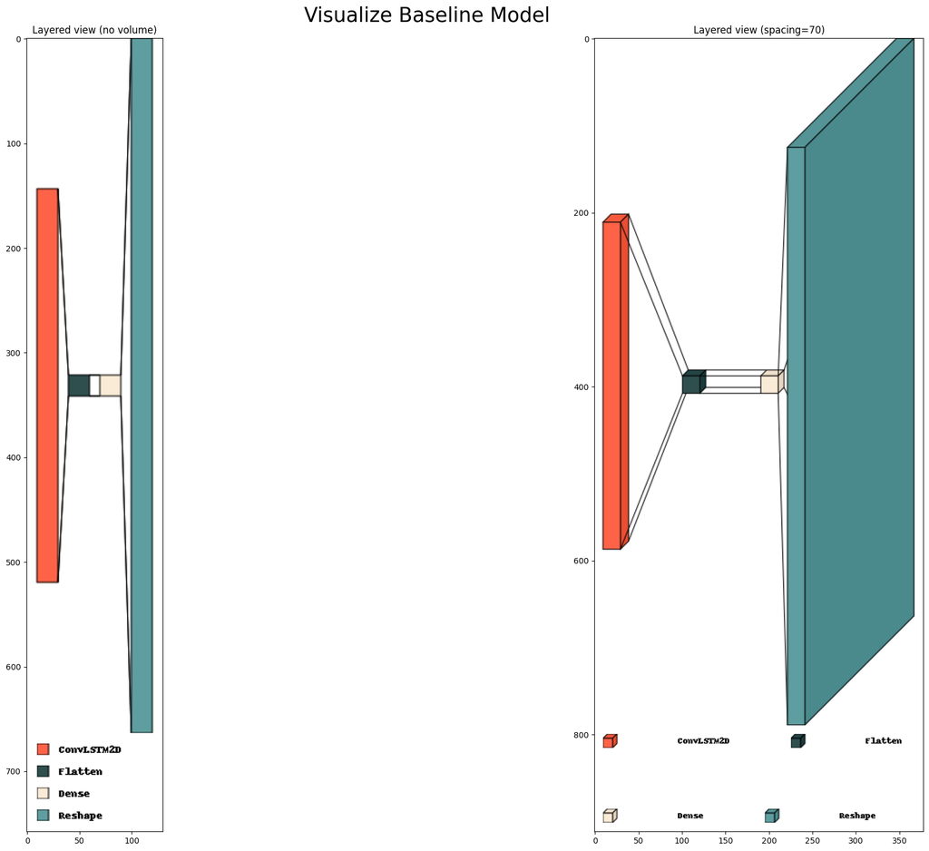

```python
fig, axs = plt.subplots(1, 2, figsize=(30, 15))
fig.suptitle('Visualize Baseline Model', fontsize=25)
axs[0].imshow(visualkeras.layered_view(baseline_model, color_map=color_map, legend=True, draw_volume=False))
axs[0].set_title('Layered view (no volume)')
axs[1].imshow(visualkeras.layered_view(baseline_model, color_map=color_map, legend=True, spacing=70))
axs[1].set_title('Layered view (spacing=70)')
plt.tight_layout()
plt.show()
```

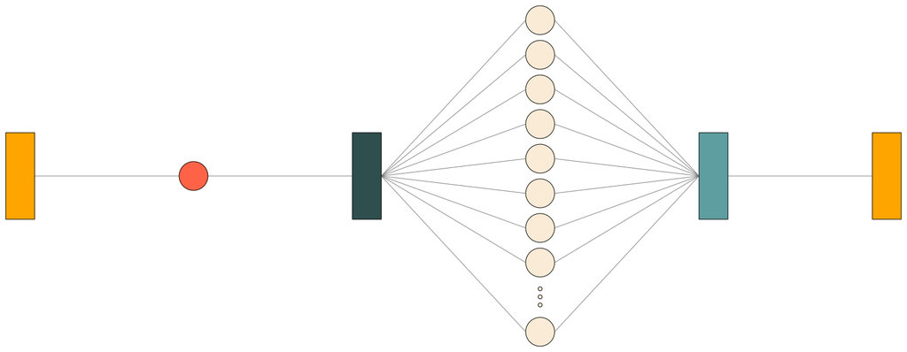

```python
visualkeras.graph_view(baseline_model, color_map=color_map)
```

```python
# Compile
baseline_model.compile(optimizer='adam', loss='mse' , metrics = ["mean_absolute_error"])
```

```python
# Train the model
#baseline_history = baseline_model.fit(train_generator, epochs=3,validation_data=val_generator)
```

```python
# baseline_model.save_weights('final_baseline_model_weights.h5')
```

```python
baseline_model.load_weights('final_baseline_model_weights.h5')
```

```python
next(iter(test_generator))
```

```python
y_pred = baseline_model.predict(X_test)

# Evaluate the predictions
baseline_model.evaluate(y_test, y_pred)
```

[output not shown]

```python
train_loss = baseline_history.history['loss']
val_loss = baseline_history.history['val_loss']
```

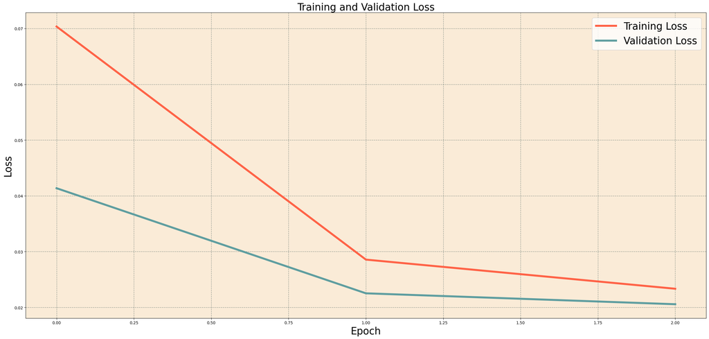

```python
fig, axes = plt.subplots(nrows=1, ncols=1, figsize=(25, 12))

axes.plot(train_loss, label='Training Loss', color='tomato', lw=5)
axes.plot(val_loss, label='Validation Loss', color='cadetblue', lw=5)
axes.set_title('Training and Validation Loss', fontsize =25)
axes.set_xlabel('Epoch', fontsize = 25)
axes.set_ylabel('Loss', fontsize = 25)
axes.legend(fontsize = 25)
axes.set_facecolor('antiquewhite')
axes.grid(color='darkslategrey', alpha=0.5, linestyle='dashed', linewidth=1)

plt.tight_layout()
plt.show()
```

```python
x, y_true = train_generator.__getitem__(0)[0], train_generator.__getitem__(0)[1]
y_pred = baseline_model.predict(x)

print("Predicted output shape:", y_pred.shape)
print("True output shape:", y_true.shape)
```

```python
print("Predicted output for the first timestep of the first image for the first row of the image:", y_pred[0][0].shape,'\n', y_pred[0][0],'\n')
print("True output for the first timestep of the first image for the first row of the image:", y_true[0][0].shape,'\n', y_true[0][0])
```

```python
test_loss, _ = baseline_model.evaluate_generator(test_generator)
print('Test loss:', test_loss)
```

## Interpret Results

We suspect the following could be the underlying issues:

## Pipeline and Future Model Plans

*In terms of modelling, we believe that using visual transformers is the best option. The main reason why we are shifting away from ConvLSTMs is because of scalability concerns: Transformers can efficiently process long sequences and large input sizes due to their self-attention mechanism, which allows them to model dependencies across the entire input sequence in parallel. ConvLSTMs, on the other hand, process the input data sequentially, which can limit their ability to scale to large input sizes and capture long-range dependencies. The second reason is because of overall performance: visual transformers have achieved SOTA performance on a wide range of computer vision tasks, outperforming traditional convolutional neural networks (CNNs) and similar architectures. The self-attention mechanism in transformers allows them to learn complex patterns and representations, leading to improved performance on tasks.*

*We are going to take advantage of the flexible architectures of transformers to combine transformer layers that we are going to train ourselves with some of the layers of Facebook AI’s SOTA DINOv2 (https://ai.facebook.com/blog/dino-v2-computer-vision-self-supervised-learning/). The pipeline and model architecture will be as follows:*

1. Tokenizing the images: divide the input images into fixed-size patches, then flatten and linearly embed these patches. This creates a sequence of tokens representing the images, which can be processed by the transformer layers.
2. Positional encoding: Add positional encodings to the image tokens to provide the model with information about the spatial location of the patches within the original image.
3. Two types of transformer layers: Fine-tuned DINOv2 at first, then multiple transformer layers. These layers enable the model to capture both local and global contextual information in the input data. We pass the tokenized images through them.
4. Prediction head: Add a prediction head to the transformer model. This will be a linear layer in this case, as we are trying to predict continuous values: the output of this head will be used to predict soil moisture values.

## Generators

- For the milestone 4, we used our model on the entire data we pulled from the Cloud that we were able to load locally. Using the TimeseriesGenerator was a great way to put the data into the desired shape (sequences of given length). However, we would like to create our own generator. This generator should be able to load only the necessary amount of data directly from our Google Cloud Bucket and put the data into the desired shape during the model training process.
- We worked on the following generator (see next code cells). So far, our generator can handle any sequence length for both x and y, but is computationally expensive when we try to fit the model on it (resources exhausted error message). This was a first try, but we do believe that we will be able to improve our generator and do some operations more efficiently. We could explore the following:
  - currently, the preprocessing is done within our generator (nan, scaling, shape), however, we could push the preprocessed data into a bucket and load directly from there (depends on our resources and if we can create one more bucket)
  - also, we believe that our generator is loading a bit more data than necessary and that we can simplify some operations to make it less computationally expensive
  - we could also reduce the size of the images to gain memory space

*The code below defines a function called `make_mask()` that generates a mask layer. The function first lists the files in a Google Cloud Platform (GCP) bucket and then downloads the GeoTIFF files that match a certain pattern, storing them in a dictionary. It then sets up a counter variable, downloads the first file of each type with a progress bar, and reads the pixel values for the first band of each file as a NumPy array. It replaces NoData values with NaN and appends the resulting tuple containing the data and file name to a list within the dictionary. It then creates a mask by copying the first GeoTIFF file, setting all non-NaN values to 0, and all NaN values to 1. Finally, it saves the mask and returns the mask image as a NumPy array. The purpose of this function is to create a binary mask for later use in a project, for masking out the ocean regions in the data in an efficient way.*

```python
def make_mask():

  """
  Helper function to generate the mask layer and save it.
  We already have one but keeping this function incase it gets deleted and need
  to create new one

  """

  #List the files in the GCP bucket
  blobs = list(bucket.list_blobs())
  #Download the GeoTIFF files and store them in the dictionary
  file_patterns = {
      'sm': re.compile(r'^smSurface_\d{4}-\d{2}-\d{2}\.tif$'),
  }

  geo_files = {key: [] for key in file_patterns}
  # Group blobs by file type
  blobs_by_type = {key: [] for key in file_patterns}
  for blob in blobs:
      file_name = blob.name
      for key, pattern in file_patterns.items():
          if pattern.match(file_name):
              blobs_by_type[key].append(blob)
  # Set counter variable
  counter = {key: 0 for key in file_patterns}
  # Download files with progress bars
  for key, blob_list in blobs_by_type.items():
      print(f'Downloading {key} files:')
      for blob in tqdm(blob_list[0:1]):
          # this if-break statement is to only download certain amount of data
          if counter[key] >= 1:
              break
          # Read the GeoTIFF file into memory and open it using rasterio
          with MemoryFile(blob.download_as_bytes()) as memfile:
              with memfile.open() as dataset:
                  # Read the pixel values for the first band as a NumPy array
                  data = dataset.read(1)
                  # Replace NoData values with NaN
                  nodata_value = dataset.nodata
                  if nodata_value is not None:
                      data[data == nodata_value] = np.nan
                  geo_files[key].append((data, blob.name)) # Append tuple containing data and file name
                  counter[key] += 1
  # Make Mask
  mask_image = geo_files['sm'][0][0].copy()
  mask_image[~np.isnan(mask_image)] = 0
  mask_image[np.isnan(mask_image)] = 1
  np.savetxt(r'/content/drive/Shareddrives/AC 209b - Project/Milestone/MS4/mask.csv', mask_image, delimiter=',')
  return mask_image
```

```python
# Load mask:
mask_path = '/content/drive/Shareddrives/AC 209b - Project/Milestone/MS4/mask.csv'
mask =  np.loadtxt(mask_path, delimiter=',')
```

*The code below defines a function called `data_generator` that takes in five parameters: `start_date`, `end_date`, `x_window_size`, `y_window_size`, and `batch_size`.*

*The function first calculates the total number of days between start_date and end_date and then uses this to compute the number of sequences and batches to create.*

*Within each batch, the function retrieves TIFF files from Google Cloud Storage (GCS) containing data for specific dates, preprocesses the data (scales, replaces NaN values with zero), and then concatenates and reshapes the data into two arrays: `X_temp` and `Y_temp`. These arrays hold the input and output data for the neural network model that will be trained using this data.*

*After processing all the data for the current batch, the function creates two arrays for the entire batch: `X` and `Y`. These arrays hold the input and output data for the neural network model that will be trained using this data. The `X` array is created by stacking arrays of data from the `X_temp` array, while the `Y` array is created by stacking arrays of data from the `Y_temp` array.*

*Finally, the function yields each batch of `X` and `Y` arrays, so that they can be fed into the neural network for training.*

```python
#connect to bucket
storage_client = storage.Client.from_service_account_json(key_file_path)
bucket = storage_client.get_bucket(bucket_name)

def data_generator(start_date, end_date, x_window_size=28, y_window_size=7, batch_size=2):
  # Compute the total number of days between start_date and end_date
  total_days = (end_date - start_date).days + 1
  # Calculate the number of sequences
  num_sequences = total_days - x_window_size - y_window_size + 1
  # Calculate the number of batches
  num_batches = round(num_sequences/batch_size)
  # Loop over the batches: use a generator to stop after each batch of data is loaded
  for batch_idx in range(num_batches):
      # Calculate the start and end dates for the current batch
      batch_start_date = start_date + timedelta(days=batch_idx)
      batch_end_date = batch_start_date + timedelta(days=x_window_size + y_window_size)

      # Master arrays/dic to yield at the end
      geo_files = {}
      X_temp = np.empty((0,94,166,4))
      Y_temp = np.empty((0,94,166))
      # Load images for the current batch from GCS, transform and append to images
      print('Generating Batch')
      for single_date in (batch_start_date + timedelta(n) for n in tqdm(range((batch_end_date - batch_start_date).days + 1))):
        #Get Date of the file
        date_file = single_date.strftime('%Y-%m-%d')
        # Download the necessary files
        file_prefixes = ['smSurface', 'precipitation', 'surface_temp', 'evapotranspiration']
        for prefix in file_prefixes:
          file_name = f'{prefix}_{date_file}.tif'
          blob = bucket.blob(file_name)

          # Load the TIFF file directly into memory without storing it locally
          url = f"https://storage.googleapis.com/{bucket_name}/{file_name}"
          blob = bucket.blob(file_name)
          content = blob.download_as_bytes()
          geo_files[prefix] = imread(io.BytesIO(content))
          # add mask layer to geofile
          geo_files['mask'] = mask
        max_sm = np.nanmax(geo_files['smSurface'])
        geo_files['smSurface'] = np.nan_to_num(geo_files['smSurface'], nan=max_sm)
        for key in list(geo_files.keys())[1:]:
          min_key = np.nanmin(geo_files[key])
          geo_files[key] = np.nan_to_num(geo_files[key], nan=min_key)

        # Preprocess the data (MinMaxScaler, replace NaN values, etc.)
        # Initialize the MinMaxScaler
        scaler = MinMaxScaler()
        # Loop through the keys in the geo_files dictionary
        for key in geo_files:
          #exclude mask
          if key != 'mask':
              # Get the current array of images
              images = geo_files[key]
              # Get the shape of the images array
              original_shape = images.shape
              # Reshape the images array to 2D for applying the scaler
              images_2d = images.reshape(-1, original_shape[-1])
              # Fit the scaler on the 2D images array and transform it
              scaled_images_2d = scaler.fit_transform(images_2d)
              # Reshape the scaled images back to their original shape
              scaled_images = scaled_images_2d.reshape(original_shape)
              # Update the images in the geo_files dictionary
              geo_files[key] = scaled_images
        # Take all values in the dictionary for all keys, and replace nan with zero and keep scaled values the same
        for key, value in geo_files.items():
            geo_files[key] = np.where(np.isnan(value), 0, value)
        # Concatenate, split, and reshape the data
        x = np.stack([np.stack(arrays, axis=0) for key, arrays in geo_files.items() if key != 'smSurface'], axis=-1)
        y = np.stack(geo_files['smSurface'], axis=0)
        #reshape to fit X_temp, Y_temp
        x = x.reshape(1,*x.shape[:])
        y = y.reshape(1,*y.shape[:])
        # concat x and y to master
        X_temp = np.concatenate((X_temp, x),axis=0)
        Y_temp = np.concatenate((Y_temp, y),axis=0)
      # Master arrays for batches
      X = np.array([X_temp[i:i+x_window_size, :, :, :] for i in range(batch_size)])
      #Y = np.array([Y_temp[i+x_window_size] for i in range(batch_size)])
      Y = np.array([Y_temp[i+x_window_size:i+x_window_size+y_window_size, :, :] for i in range(batch_size)])
      # Yield the batches of images

      # for (x,y) in zip(X,Y):
      #   x[np.isinf(x)] = np.nan
      #   y[np.isinf(y)] = np.nan

      yield X, Y
```

```python
 # test the generator
 start_date = datetime(year=2018, month=4, day=1)
 end_date = datetime(year=2018, month=4, day=9)
 batch_size = 2
 x_window_size = 7
 y_window_size = 1
 # initialize generator:
 train_gen = data_generator(start_date, end_date, x_window_size=x_window_size, y_window_size=y_window_size, batch_size=batch_size)
 # Generate data untill stopage:
 i=0
 while i <1:
   try:
     x_batch,y_batch = next(train_gen)
     print(f'batch: {i+1}, x_shape: {x_batch.shape} , y_shape{y_batch.shape}')
     i+=1
   except StopIteration:
     pass
```

# Scoring ViT

```python
## Yanis

# Adding number of timesteps
# Define the training parameters
batch_size = 1
learning_rate = 1e-3
num_epochs = 10

in_channels  =  4
num_timesteps = batch_size*window_inputs[0].shape[0]


# Define the model architecture
class VisualTransformer(nn.Module):
    def __init__(
        self,
        image_width=new_width,
        image_height=new_height,
        patch_size=20,
        hidden_size=256,
        num_layers=2,
        num_heads=8,
        dropout=0,
        num_timesteps=num_timesteps,
    ):
        super().__init__()
        self.patch_size = patch_size
        self.image_width = image_width
        self.image_height = image_height
        self.hidden_size = hidden_size
        self.num_layers = num_layers
        self.num_heads = num_heads
        self.dropout = dropout
        self.num_timesteps = num_timesteps

        # Compute the number of patches per dimension
        self.num_patches_width = image_width // patch_size
        self.num_patches_height = image_height // patch_size
        self.num_patches = self.num_patches_width * self.num_patches_height

        # Define the patch embedding layer
        self.patch_embed = nn.Conv2d(
            in_channels=in_channels,
            out_channels=hidden_size,
            kernel_size=self.patch_size,
            stride=self.patch_size,
        )

        # Define the positional encoding layer for spatial and temporal information
        self.pos_embed = nn.Parameter(
            torch.randn(self.num_timesteps, self.num_patches, hidden_size)
        )

        # Define the transformer encoder layers
        self.transformer_layers = nn.ModuleList(
            [
                nn.TransformerEncoderLayer(
                    d_model=hidden_size, nhead=num_heads, dropout=dropout
                )
                for _ in range(num_layers)
            ]
        )

        # Define the final classification layer
        # self.classifier = nn.Linear(
        #     self.hidden_size,
        #     batch_size * y_window * self.image_width * self.image_height,
        # )
        self.classifier = nn.Sequential(nn.Linear(
            self.hidden_size,
            batch_size*y_window*self.image_width*self.image_height),
            nn.Sigmoid())

    def forward(self, x):
        # Reshape the input tensor to have 4 dimensions
        x = x.view(x.shape[0], x.shape[2], x.shape[1], x.shape[3])


        # Apply the patch embedding layer to the input image
        x = self.patch_embed(x)


        # Reshape the output of the patch embedding layer to have a sequence length of num_patches
        b, c, h, w = x.shape
        x = x.view(b, c, -1).transpose(1, 2)


        # Add the positional encodings to the patches, accounting for both spatial and temporal positions
        x = x + self.pos_embed


        # Apply the transformer encoder layers to the patches
        for layer in self.transformer_layers:
            x = layer(x)

        # Compute the mean of the patches as the representation of the entire image
        x = x.mean(dim=1)


        # Apply the final classification layer and return the output
        x = self.classifier(x)

        x = x.mean(dim=0)

        x = x.view(batch_size, y_window, self.image_height, self.image_width)

        return x
```

```python
# Prior: N(0,1)
# Define the training parameters
batch_size = 1
learning_rate = 1e-3
num_epochs = 10
num_timesteps = batch_size*28


import torch
import torch.nn as nn
import pyro
from pyro.nn import PyroModule, PyroSample
from pyro.distributions import Normal


class BayesianVisualTransformer(PyroModule, nn.Module):
    def __init__(
        self,
        image_width=width,
        image_height=height,
        patch_size=20,
        hidden_size=256,
        num_layers=2,
        num_heads=8,
        dropout=0.1,
        num_timesteps=num_timesteps,
    ):
        PyroModule.__init__(self)  # BAYESIAN: Initialize PyroModule
        nn.Module.__init__(self)
        self.patch_size = patch_size
        self.image_width = image_width
        self.image_height = image_height
        self.hidden_size = hidden_size
        self.num_layers = num_layers
        self.num_heads = num_heads
        self.dropout = dropout
        self.num_timesteps = num_timesteps

        self.num_patches_width = image_width // patch_size
        self.num_patches_height = image_height // patch_size
        self.num_patches = self.num_patches_width * self.num_patches_height

        # BAYESIAN: Wrap the Conv2d layer with PyroModule and define the prior distributions for its parameters
        self.patch_embed = PyroModule[nn.Conv2d](
            in_channels=in_channels,
            out_channels=hidden_size,
            kernel_size=self.patch_size,
            stride=self.patch_size,
        )
        self.patch_embed.weight = PyroSample(
            Normal(0.0, 1.0)
            .expand([hidden_size, in_channels, self.patch_size, self.patch_size])
            .to_event(4)
        )
        self.patch_embed.bias = PyroSample(
            Normal(0.0, 1.0).expand([hidden_size]).to_event(1)
        )

        self.pos_embed = nn.Parameter(
            torch.randn(self.num_timesteps, self.num_patches, hidden_size)
        )

        # BAYESIAN: Wrap the TransformerEncoderLayer with PyroModule
        self.transformer_layers = nn.ModuleList(
            [
                PyroModule[nn.TransformerEncoderLayer](
                    d_model=hidden_size, nhead=num_heads, dropout=dropout
                )
                for _ in range(num_layers)
            ]
        )



        # BAYESIAN: Wrap the Linear layer with PyroModule and define the prior distributions for its parameters
        self.classifier = nn.Sequential(
            PyroModule[nn.Linear](
                self.hidden_size,
                batch_size * y_window * self.image_width * self.image_height,
            ),
            nn.Sigmoid()
        )
        self.classifier[0].weight = PyroSample(
            Normal(0.0, 1.0)
            .expand(
                [
                    batch_size * y_window * self.image_width * self.image_height,
                    self.hidden_size,
                ]
            )
            .to_event(2)
        )
        self.classifier[0].bias = PyroSample(
            Normal(0.0, 1.0)
            .expand([batch_size * y_window * self.image_width * self.image_height])
            .to_event(1)
        )


    def forward(self, x):
        x = x.view(x.shape[0], x.shape[2], x.shape[1], x.shape[3])

        x = self.patch_embed(x)

        b, c, h, w = x.shape
        x = x.view(b, c, -1).transpose(1, 2)

        x = x + self.pos_embed

        for layer in self.transformer_layers:
            x = layer(x)

        x = x.mean(dim=1)

        # Apply the final classification layer and return the output
        x = self.classifier(x)
        x = x.mean(dim=0)
        x = x.view(batch_size, y_window, self.image_height, self.image_width)
        return x
```

```python
# Instantiating the model:

vit = VisualTransformer()
bayesian_vit = BayesianVisualTransformer()
```

```python
# Loading weights for vanilla VIT

bucket_name = "smap-satellite-images-reduced"
weights_file = "model_weights/VIT_v7_elaine_project_idea.pth"

# Authenticate with GCP
storage_client = storage.Client()
bucket = storage_client.bucket(bucket_name)

# Download the file to memory
blob = bucket.blob(weights_file)
data = blob.download_as_string()

# Load the weights into the model
state_dict = torch.load(io.BytesIO(data))
vit.load_state_dict(state_dict)
```

[output not shown]

```python
# Load weights for Bayesian ViT

weights_file = "model-weights/VIT_v8_bayesian_vit.pth"

blob = bucket.blob(weights_file)
data = blob.download_as_string()

# Load the weights into the model
state_dict = torch.load(io.BytesIO(data))
bayesian_vit.load_state_dict(state_dict)
```

```python
# Test VIT
vit.eval()  # Set the model to evaluation mode
mse_loss = nn.MSELoss(reduction="mean")
mape_loss = nn.L1Loss(reduction="mean")
total_mse_loss = 0
total_mape_loss = 0

with torch.no_grad(), tqdm(total=len(test_dataloader), desc="Testing") as pbar:
    for i, ((data, mask), true_values) in enumerate(
        zip(test_dataloader, window_outputs)
    ):
        data = data.to(device)
        mask = mask.to(device)
        output = vit(data)
        loss_mse = mse_loss(output, true_values)
        loss_mape = mape_loss(output, true_values)
        total_mse_loss += loss_mse.item()
        total_mape_loss += loss_mape.item()
        pbar.update(1)

# Calculate and print the average loss over the test set
avg_mse_loss = total_mse_loss / len(window_outputs)
avg_mape_loss = total_mape_loss / len(window_outputs)
print("Average MSE loss on test set: ", avg_mse_loss)
print("Average MAPE loss on test set: ", avg_mape_loss)
```